# SARIMA Home Sales Index in US

#Import Data

```r
library("tseries")
     library("forecast")
     library("TTR")
     library("TSA")
```

```r
     library("graphics")
     library("astsa")
     library("car")
     library("portes")
Index <- read.csv("C:\\Users\\Lusi Oktaviani\\OneDrive\\Statistics and Data Science\\Semester 5\\MPDW\\Praktikum\\Index.csv")
View(Index)
```

```r
index.ts <- ts(Index$Index, frequency = 12, start = c(2000,1), end = c(2019,12))
class(index.ts)
```

```
## [1] "ts"
```

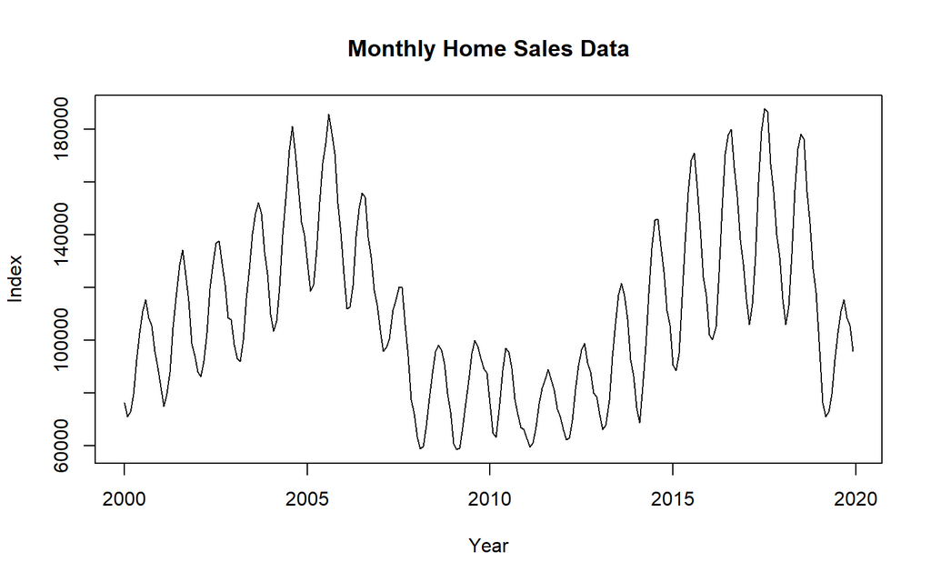

```r
plot.ts(index.ts, main = "Monthly Home Sales Data", xlab = "Year",ylab = "Index")
```

Plot data asal memperlihatkan pola musiman dengan s = 12, serta terdapat perilaku nonstasioner baik dalam rataan maupun ragam.

## Plot per musim

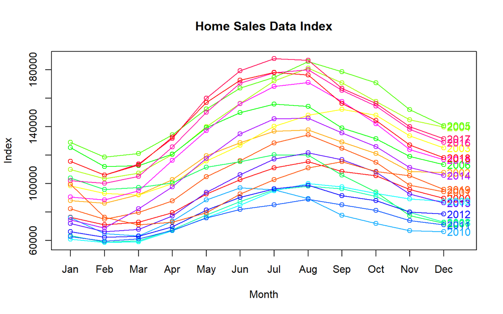

```r
seasonplot(index.ts,12,main="Home Sales Data Index", ylab="Index",year.labels = TRUE, col=rainbow(18))
```

## Deskriptif Index

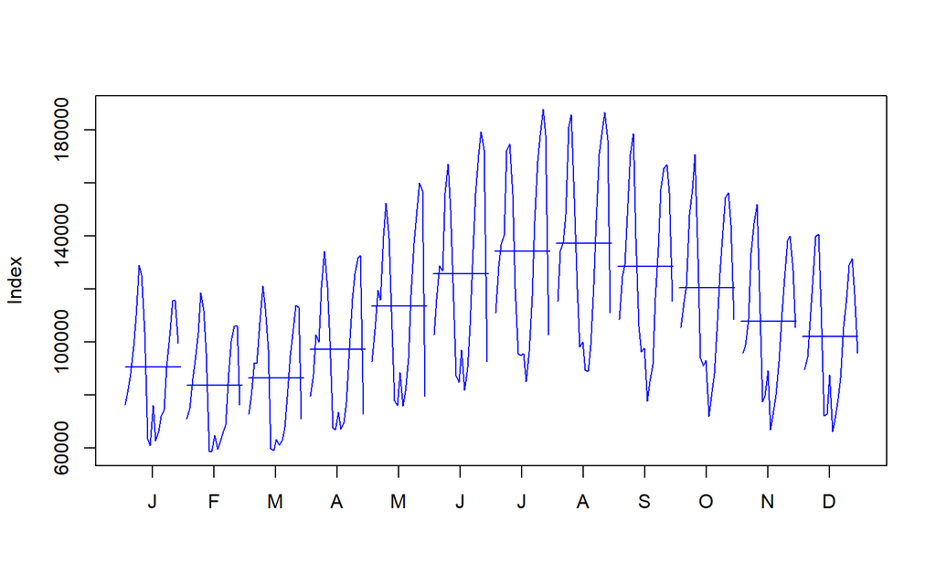

```r
monthplot(index.ts,ylab="Index", col="blue")
```

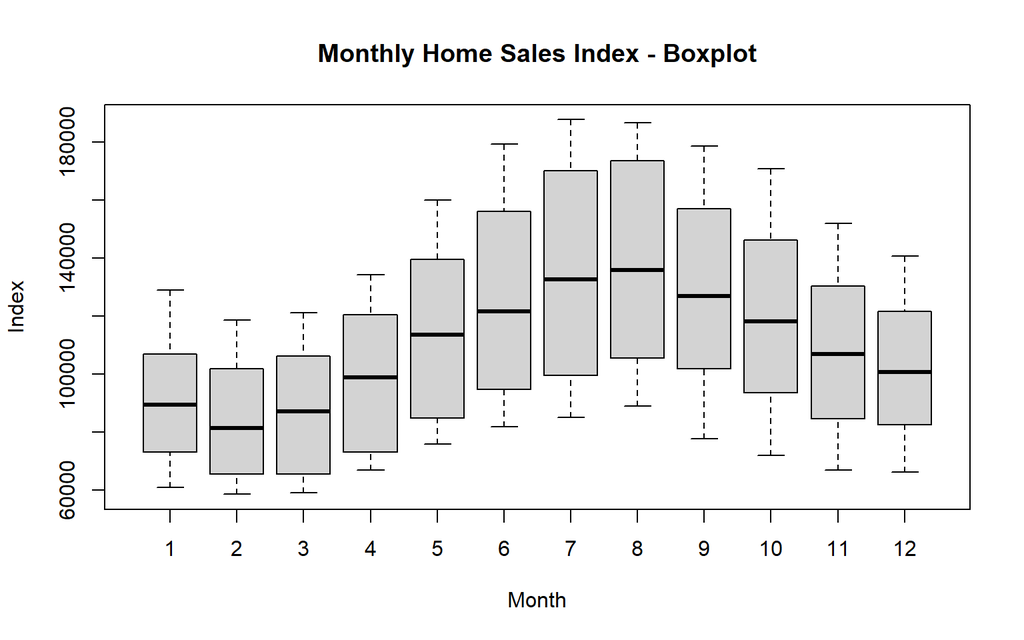

```r
boxplot(index.ts ~ cycle(index.ts), xlab = "Month", ylab = "Index", main = "Monthly Home Sales Index - Boxplot")
```

Boxplot menunjukkan ukuran keragaman (panjang box) dan pemusatan (median) yang berbeda pada masing-masing bulan

# Identifikasi Model

## Transformasi Logaritma

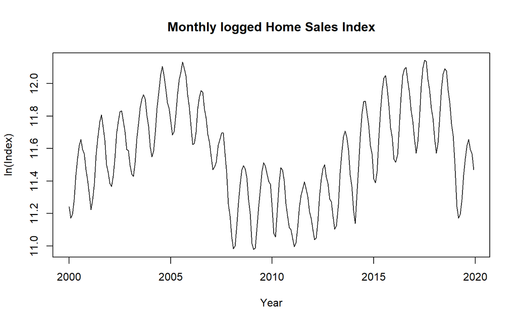

```r
lnIndex=log(index.ts)
plot.ts(lnIndex, main = "Monthly logged Home Sales Index", xlab = "Year", ylab = "ln(Index)")
```

Transformasi logaritma berhasil mengatasi ketidakstasioneran dalam ragam meskipun ketidakstasioneran dalam rataan masih nampak.

## Deskriptif in Home sales index

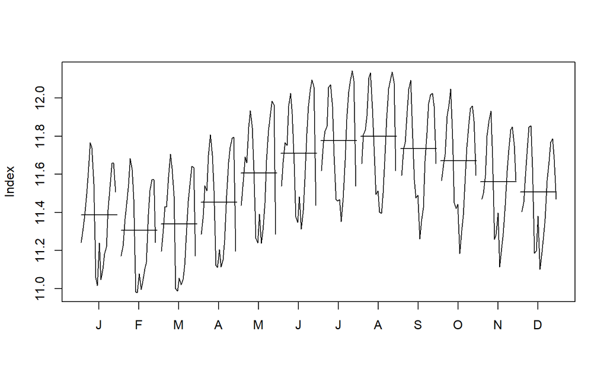

```r
monthplot(lnIndex,ylab="Index")
```

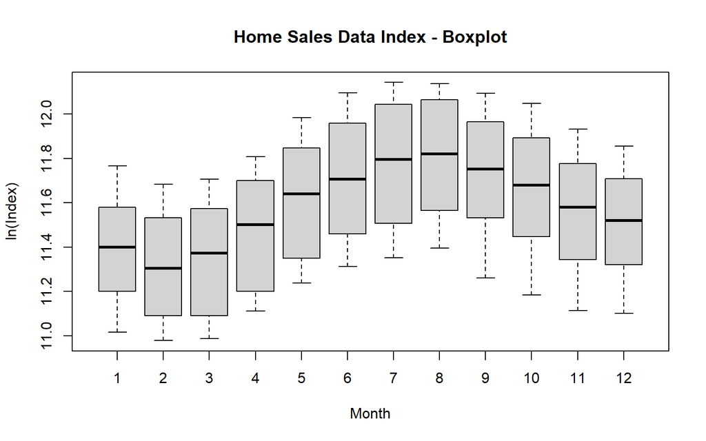

```r
boxplot(lnIndex ~ cycle(lnIndex), xlab = "Month", ylab = "ln(Index)", main = "Home Sales Data Index - Boxplot")
```

Boxplot menunjukkan ukuran keragaman (panjang box) hampir sama akan tetapi ukuran pemusatan (median) yang berbeda pada masing-masing bulan ## Tes kehomogenan ragam

```r
fligner.test(Index ~ Date, data=Index)
```

```
##
##  Fligner-Killeen test of homogeneity of variances
##
## data:  Index by Date
## Fligner-Killeen:med chi-squared = 54.055, df = 19, p-value = 3.24e-05
```

Nilai-p kurang dari 5% sehinga tolak H0 dengan kata lain ragam tidak homogen

```r
fligner.test(log(Index)~ Date, data=Index)
```

```
##
##  Fligner-Killeen test of homogeneity of variances
##
## data:  log(Index) by Date
## Fligner-Killeen:med chi-squared = 20.114, df = 19, p-value = 0.3877
```

Nilai-p lebih dari 5% sehingga tidak tolak H0 dengan kata lain ragam data setelah di ln kan homogen

## Pembagian data lnIndex menjadi training-testing

```r
lind<- subset(lnIndex,start=1,end=181)
     test <- subset(lnIndex,start=182,end=228)
```

## Identifikasi kestasioneran data Ln Index

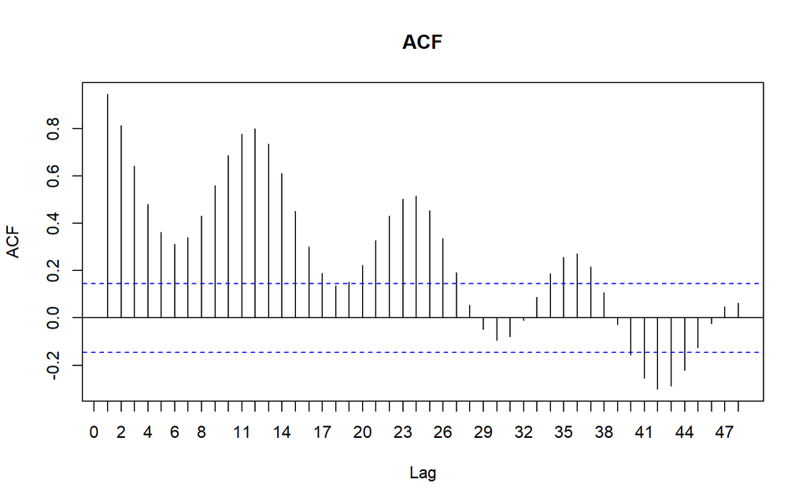

```r
acf0<-acf(lind,main="ACF",lag.max=48,xaxt="n")
     axis(1, at=0:48/12, labels=0:48)
```

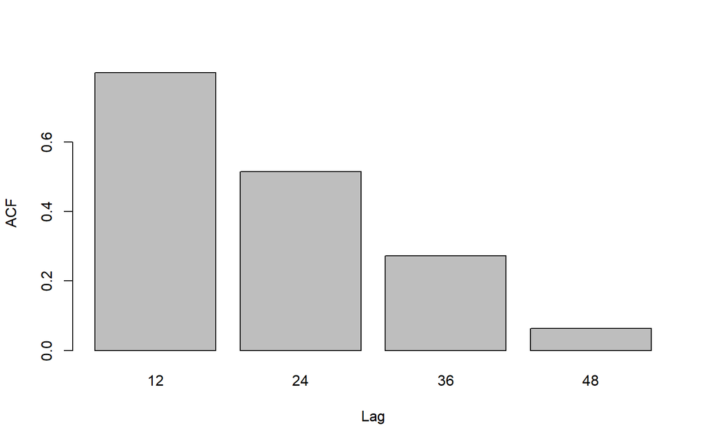

```r
acf0$lag=acf0$lag*12
     acf0.1 <- as.data.frame(cbind(acf0$acf,acf0$lag))
     acf0.2 <- acf0.1[which(acf0.1$V2%%12==0),]
     barplot(height = acf0.2$V1, names.arg=acf0.2$V2, ylab="ACF", xlab="Lag")
```

Plot ACF menunjukkan data ln US Pass tidak stasioner baik di series non musiman maupun musiman

## Melakukan proses pembedaan pertama pada series non musiman data lnIndex

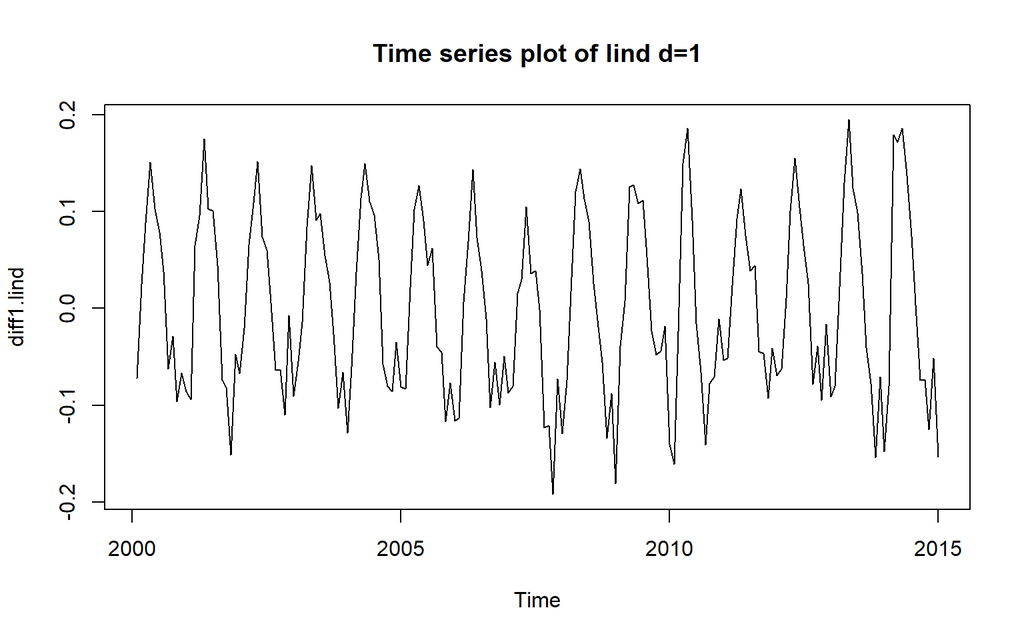

```r
diff1.lind=diff(lind)
     plot(diff1.lind, main = "Time series plot of lind d=1")
```

Differencing non musiman d = 1 berhasil mengatasi ketidakstasioneran dalam rataan untuk komponen non musimannya. ## Identifikasi kestasioneran data Ln Index

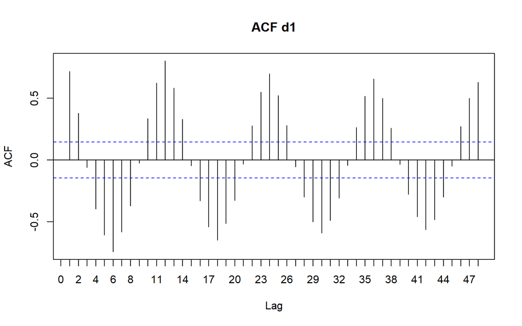

```r
acf1 <- acf(diff1.lind,lag.max=48,xaxt="n", main="ACF d1")
     axis(1, at=0:48/12, labels=0:48)
```

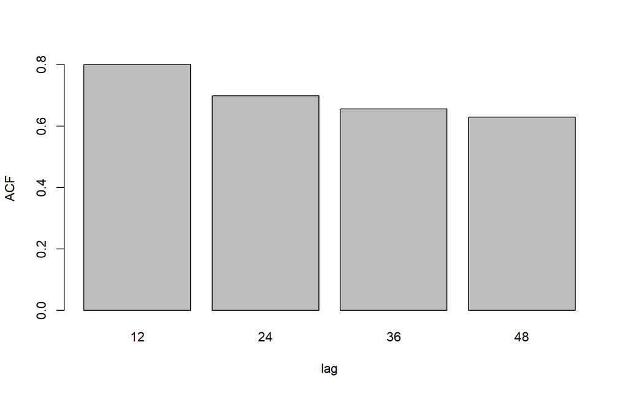

```r
acf1$lag <- acf1$lag * 12
     acf1.1 <- as.data.frame(cbind(acf1$acf,acf1$lag))
     acf1.2 <- acf1.1[which(acf1.1$V2%%12==0),]
     barplot(height=acf1.2$V1,names.arg=acf1.2$V2,ylab="ACF",xlab="lag")
```

### Melakukan proses pembedaan pada series musiman

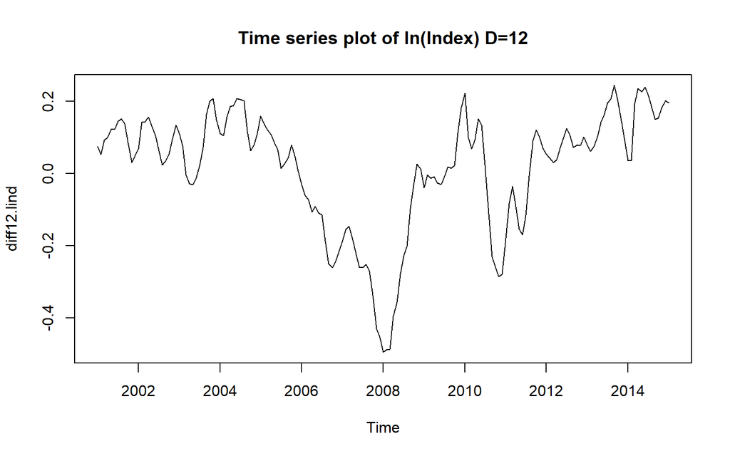

```r
diff12.lind <- diff(lind,12)
     plot(diff12.lind, main = "Time series plot of ln(Index) D=12")
     axis(1, at=0:48/12, labels=0:48)
```

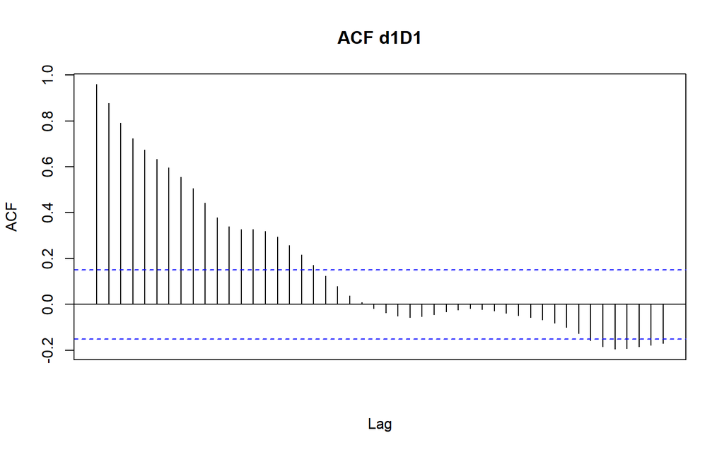

```r
acf2<- acf(diff12.lind,lag.max=48,xaxt="n", main="ACF d1D1")
```

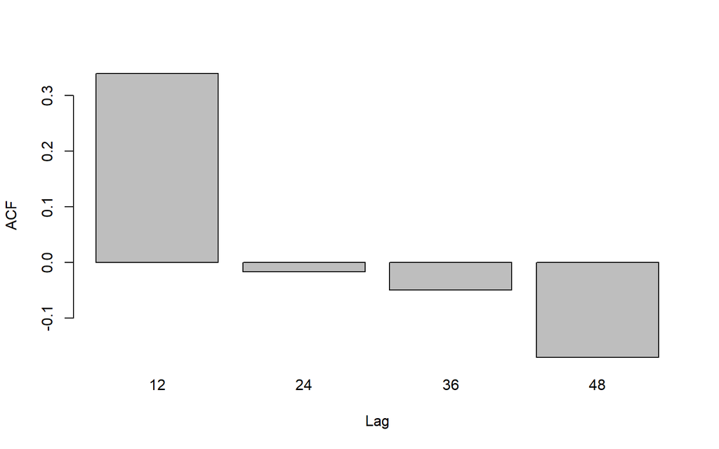

```r
acf2$lag <- acf2$lag * 12
     acf2.1 <- as.data.frame(cbind(acf2$acf,acf2$lag))
     acf2.2 <- acf2.1[which(acf2.1$V2%%12==0),]
     barplot(height=acf2.2$V1,names.arg=acf2.2$V2,ylab="ACF", xlab="Lag")
```

###Melakukan pembedaan pertama pada data yang telah dilakukan pembedaan pada series musimannya

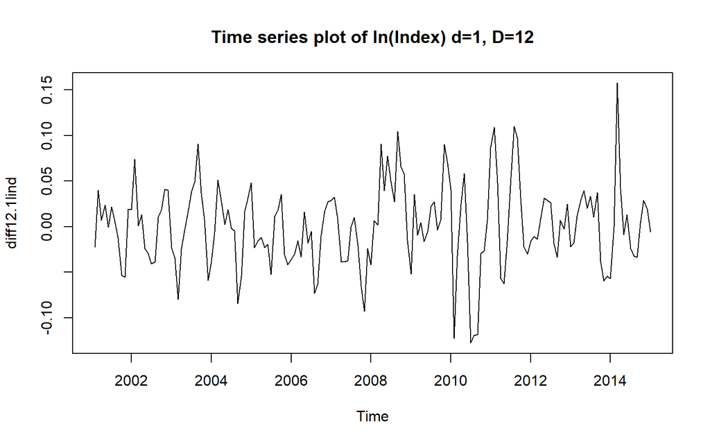

```r
diff12.1lind <- diff(diff12.lind,1)
     plot(diff12.1lind, main = "Time series plot of ln(Index) d=1, D=12")
```

## Identifikasi Model

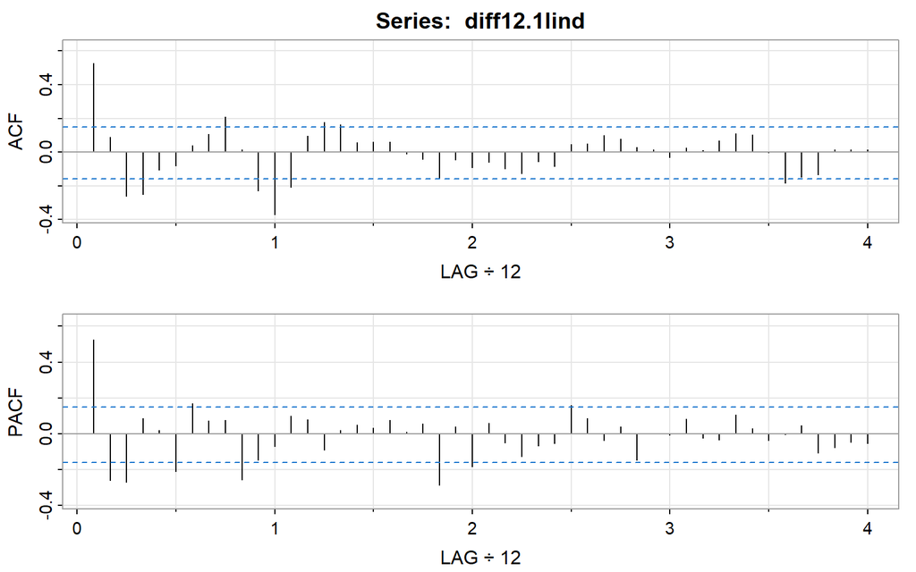

```
##      [,1]  [,2]  [,3]  [,4]  [,5]  [,6] [,7] [,8] [,9] [,10] [,11] [,12] [,13]
## ACF  0.53  0.09 -0.26 -0.25 -0.11 -0.08 0.04 0.11 0.21  0.02 -0.23 -0.37 -0.21
## PACF 0.53 -0.26 -0.27  0.08  0.02 -0.21 0.17 0.07 0.07 -0.26 -0.15 -0.07  0.10
##      [,14] [,15] [,16] [,17] [,18] [,19] [,20] [,21] [,22] [,23] [,24] [,25]
## ACF   0.09  0.18  0.16  0.06  0.06  0.06 -0.01 -0.04 -0.16 -0.04 -0.09 -0.06
## PACF  0.08 -0.09  0.02  0.05  0.03  0.08  0.01  0.05 -0.29  0.04 -0.18  0.06
##      [,26] [,27] [,28] [,29] [,30] [,31] [,32] [,33] [,34] [,35] [,36] [,37]
## ACF  -0.10 -0.13 -0.06 -0.08  0.05  0.05  0.10  0.08  0.03  0.01 -0.03  0.03
## PACF -0.05 -0.13 -0.07 -0.05  0.16  0.08 -0.04  0.04 -0.15  0.00 -0.01  0.08
##      [,38] [,39] [,40] [,41] [,42] [,43] [,44] [,45] [,46] [,47] [,48]
## ACF   0.01  0.07  0.11  0.10  0.00 -0.18 -0.15 -0.14  0.02  0.01  0.01
## PACF -0.02 -0.03  0.11  0.03 -0.04  0.00  0.04 -0.11 -0.08 -0.05 -0.06
```

```r
acf2(diff12.1lind,48)
```

Kedua komponen telah stasioner. Identifikasi komponen non musiman adalah ARIMA(0,1,2). Identifikasi komponen musiman adalah ARIMA(0,1,1)12, sehingga model tentatif adalah ARIMA(0,1,2)×(0,1,1)12.

```r
eacf(diff12.1lind)
```

```
## AR/MA
##   0 1 2 3 4 5 6 7 8 9 10 11 12 13
## 0 x o x x o o o o x o x  x  x  o
## 1 x o x x o o o o x o o  x  x  x
## 2 x x x x o x o o o o o  o  x  x
## 3 x o x x x o o o o o o  o  o  x
## 4 x o x o x o o o o o o  o  o  x
## 5 o x x o x o o o o o o  o  o  x
## 6 x x o o o o o o o o o  x  o  o
## 7 x o x o o o o o o o o  x  o  o
```

```r
auto.arima(lind)
```

```
## Series: lind
## ARIMA(1,1,2)(1,1,0)[12]
##
## Coefficients:
##          ar1     ma1     ma2     sar1
##       0.0137  0.5577  0.4887  -0.3668
## s.e.  0.1374  0.1168  0.0783   0.0820
##
## sigma^2 = 0.001203:  log likelihood = 327.83
## AIC=-645.65   AICc=-645.28   BIC=-630.03
```

# Pendugaan Parameter Model

## ARIMA (0,1,2) x (0,1,1)12

```r
model1 <- Arima(lind,order=c(0,1,2),seasonal=c(0,1,1))
     summary(model1)
```

```
## Series: lind
## ARIMA(0,1,2)(0,1,1)[12]
##
## Coefficients:
##          ma1     ma2     sma1
##       0.5223  0.4477  -0.9996
## s.e.  0.0662  0.0728   0.1979
##
## sigma^2 = 0.0008071:  log likelihood = 345.94
## AIC=-683.88   AICc=-683.63   BIC=-671.38
##
## Training set error measures:
##                        ME       RMSE        MAE         MPE      MAPE      MASE
## Training set -0.001232386 0.02712415 0.01892281 -0.01029753 0.1649531 0.1418456
##                    ACF1
## Training set 0.02546371
```

## ARIMA (1,1,2) x (1,1,0)12

```r
model2<-Arima(lind,order=c(1,1,2),seasonal=c(1,1,0))
     summary(model2)
```

```
## Series: lind
## ARIMA(1,1,2)(1,1,0)[12]
##
## Coefficients:
##          ar1     ma1     ma2     sar1
##       0.0137  0.5577  0.4887  -0.3668
## s.e.  0.1374  0.1168  0.0783   0.0820
##
## sigma^2 = 0.001203:  log likelihood = 327.83
## AIC=-645.65   AICc=-645.28   BIC=-630.03
##
## Training set error measures:
##                        ME       RMSE        MAE         MPE      MAPE      MASE
## Training set 6.039858e-05 0.03302171 0.02362228 0.001164113 0.2059944 0.1770728
##                     ACF1
## Training set 0.009049011
```

## ARIMA (1,1,2) x (1,1,1)12

```r
model3<-Arima(lind,order=c(1,1,2),seasonal=c(1,1,1))
     summary(model3)
```

```
## Series: lind
## ARIMA(1,1,2)(1,1,1)[12]
##
## Coefficients:
##         ar1     ma1     ma2    sar1     sma1
##       0.058  0.4963  0.4238  0.0940  -0.9999
## s.e.  0.149  0.1315  0.0847  0.0987   0.1287
##
## sigma^2 = 0.0008214:  log likelihood = 346.51
## AIC=-681.02   AICc=-680.5   BIC=-662.28
##
## Training set error measures:
##                        ME       RMSE        MAE          MPE      MAPE
## Training set -0.001094928 0.02719724 0.01908144 -0.009083655 0.1663772
##                   MASE       ACF1
## Training set 0.1430346 0.01134401
```

# Seleksi Model

##Pengujian parameter model

```r
printstatarima <- function (x, digits = 4,se=TRUE){
       if (length(x$coef) > 0) {
         cat("\nCoefficients:\n")
         coef <- round(x$coef, digits = digits)
         if (se && nrow(x$var.coef)) {
           ses <- rep(0, length(coef))
           ses[x$mask] <- round(sqrt(diag(x$var.coef)), digits = digits)
           coef <- matrix(coef, 1, dimnames = list(NULL, names(coef)))
           coef <- rbind(coef, s.e. = ses)
           statt <- coef[1,]/ses
           pval  <- 2*pt(abs(statt), df=length(x$residuals)-1, lower.tail = FALSE)
           coef <- rbind(coef, t=round(statt,digits=digits),sign.=round(pval,digits=digits))
           coef <- t(coef)
         }
         print.default(coef, print.gap = 2)
       }
     }
```

```r
printstatarima(model1)
```

```
##
## Coefficients:
##                  s.e.        t  sign.
## ma1    0.5223  0.0662   7.8897      0
## ma2    0.4477  0.0728   6.1497      0
## sma1  -0.9996  0.1979  -5.0510      0
```

```r
printstatarima(model2)
```

```
##
## Coefficients:
##                  s.e.        t   sign.
## ar1    0.0137  0.1374   0.0997  0.9207
## ma1    0.5577  0.1168   4.7748  0.0000
## ma2    0.4887  0.0783   6.2414  0.0000
## sar1  -0.3668  0.0820  -4.4732  0.0000
```

```r
printstatarima(model3)
```

```
##
## Coefficients:
##                  s.e.        t   sign.
## ar1    0.0580  0.1490   0.3893  0.6975
## ma1    0.4963  0.1315   3.7741  0.0002
## ma2    0.4238  0.0847   5.0035  0.0000
## sar1   0.0940  0.0987   0.9524  0.3422
## sma1  -0.9999  0.1287  -7.7692  0.0000
```

Model terbaik adalah model 1 karena semua dugaan parameternya berpengaruh nyata. Jika ada beberapa model yang semua dugaan parameternya nyata maka yang dipilih adalah yang nilai keakuratannya paling tinggi.

### Diagnostik model

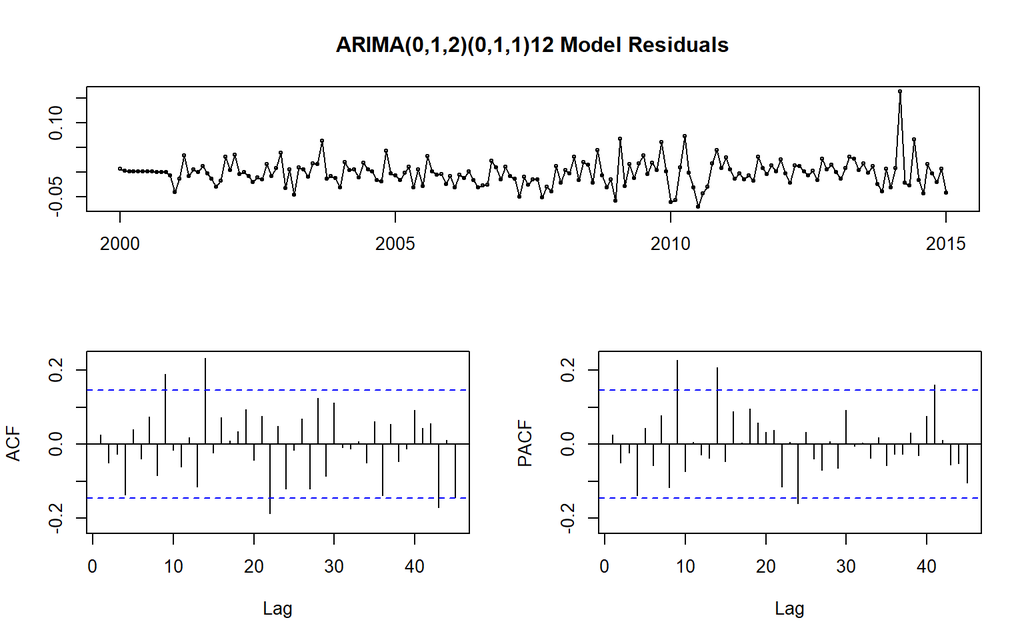

```r
tsdisplay(residuals(model1), lag.max=45, main='ARIMA(0,1,2)(0,1,1)12 Model Residuals')
```

```r
library(portes)
     ljbtest <- LjungBox(residuals(model1),lags=seq(5,30,5))
     ljbtest
```

```
##  lags statistic df     p-value
##     5  4.503723  5 0.479385438
##    10 14.139277 10 0.166733022
##    15 28.334581 15 0.019566099
##    20 31.876185 20 0.044635624
##    25 43.909727 25 0.011100153
##    30 55.796633 30 0.002880952
```

terdapat autokorelasi pada sisaan

```r
library(tseries)
     jarque.bera.test(residuals(model1))
```

```
##
##  Jarque Bera Test
##
## data:  residuals(model1)
## X-squared = 436.04, df = 2, p-value < 2.2e-16
```

Sisaan tidak menyebar normal

# Melakukan Peramalan menggunakan Model Terbaik

## Validasi Model

```r
ramalan_arima = forecast(model1, 12)
     accuracy(ramalan_arima,test)
```

```
##                        ME       RMSE        MAE         MPE      MAPE      MASE
## Training set -0.001232386 0.02712415 0.01892281 -0.01029753 0.1649531 0.1418456
## Test set      0.204607229 0.21421547 0.20460723  1.73075232 1.7307523 1.5337377
##                    ACF1 Theil's U
## Training set 0.02546371        NA
## Test set     0.58740109  1.859561
```

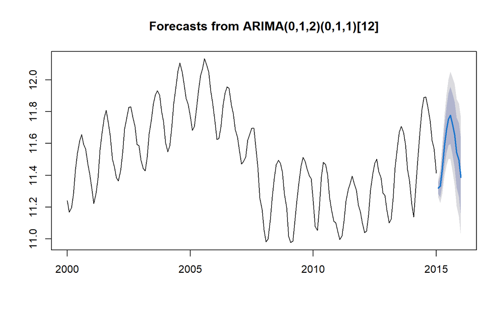

```r
plot(ramalan_arima)
```